# Portfolio 1 - Analysis of Cycling Data

```python
import pandas as pd
import numpy as np
from matplotlib import pyplot as plt
from datetime import timedelta
plt.style.use('seaborn')
%matplotlib inline
```

## Loading Data

The first dataset is an export of my ride data from [Strava](https://strava.com/), an online social network site for cycling and other sports. This data is a log of every ride since the start of 2018 and contains summary data like the distance and average speed. It was exported using the script `stravaget.py` which uses the stravalib module to read data. Some details of the fields exported by that script can be seen in [the documentation for stravalib](https://pythonhosted.org/stravalib/api.html#stravalib.model.Activity).

The exported data is a CSV file so that's easy to read, however the date information in the file is recorded in a different timezone (UTC) so we need to do a bit of conversion. In reading the data I'm setting the index of the data frame to be the datetime of the ride.

```python
strava = pd.read_csv('data/strava_export.csv', index_col='date', parse_dates=True)
strava.head()
```

| date | average_heartrate | average_temp | average_watts | device_watts | distance | elapsed_time | elevation_gain | kudos | moving_time | workout_type |
| --- | --- | --- | --- | --- | --- | --- | --- | --- | --- | --- |
| 2018-01-02 20:47:51+00:00 | 100.6 | 21.0 | 73.8 | False | 15.2 | 94 | 316.00 m | 10 | 73 | Ride |
| 2018-01-04 01:36:53+00:00 | NaN | 24.0 | 131.7 | False | 18.0 | 52 | 236.00 m | 5 | 46 | Ride |
| 2018-01-04 02:56:00+00:00 | 83.1 | 25.0 | 13.8 | False | 0.0 | 3 | 0.00 m | 2 | 2 | Ride |
| 2018-01-04 05:37:04+00:00 | 110.1 | 24.0 | 113.6 | False | 22.9 | 77 | 246.00 m | 8 | 64 | Ride |
| 2018-01-05 19:22:46+00:00 | 110.9 | 20.0 | 147.7 | True | 58.4 | 189 | 676.00 m | 12 | 144 | Ride |

#### Here, we read the CSV File and displayed the dataframe with 'date' as the index.

The second dataset comes from an application called [GoldenCheetah](https://www.goldencheetah.org/) which provides some analytics services over ride data. This has some of the same fields but adds a lot of analysis of the power, speed and heart rate data in each ride. This data overlaps with the Strava data but doesn't include all of the same rides.

Again we create an index using the datetime for each ride, this time combining two columns in the data (date and time) and localising to Sydney so that the times match those for the Strava data.

```python
cheetah = pd.read_csv('data/cheetah.csv', skipinitialspace=True)
cheetah.index = pd.to_datetime(cheetah['date'] + ' ' + cheetah['time'])
cheetah.index = cheetah.index.tz_localize('Australia/Sydney')
cheetah.head()
```

|  | date | time | filename | axPower | aPower Relative Intensity | aBikeScore | Skiba aVI | aPower Response Index | aIsoPower | aIF | ... | Rest AVNN | Rest SDNN | Rest rMSSD | Rest PNN50 | Rest LF | Rest HF | HRV Recovery Points | NP | IF | TSS |
| --- | --- | --- | --- | --- | --- | --- | --- | --- | --- | --- | --- | --- | --- | --- | --- | --- | --- | --- | --- | --- | --- |
| 2018-01-28 06:39:49+11:00 | 01/28/18 | 06:39:49 | 2018_01_28_06_39_49.json | 202.211 | 0.75452 | 16.6520 | 1.31920 | 1.67755 | 223.621 | 0.83441 | ... | 0 | 0 | 0 | 0 | 0 | 0 | 0 | 222.856 | 0.83155 | 20.2257 |
| 2018-01-28 07:01:32+11:00 | 01/28/18 | 07:01:32 | 2018_01_28_07_01_32.json | 226.039 | 0.84343 | 80.2669 | 1.21137 | 1.54250 | 246.185 | 0.91860 | ... | 0 | 0 | 0 | 0 | 0 | 0 | 0 | 245.365 | 0.91554 | 94.5787 |
| 2018-02-01 08:13:34+11:00 | 02/01/18 | 08:13:34 | 2018_02_01_08_13_34.json | 0.000 | 0.00000 | 0.0000 | 0.00000 | 0.00000 | 0.000 | 0.00000 | ... | 0 | 0 | 0 | 0 | 0 | 0 | 0 | 0.000 | 0.00000 | 0.0000 |
| 2018-02-06 08:06:42+11:00 | 02/06/18 | 08:06:42 | 2018_02_06_08_06_42.json | 221.672 | 0.82714 | 78.8866 | 1.35775 | 1.86002 | 254.409 | 0.94929 | ... | 0 | 0 | 0 | 0 | 0 | 0 | 0 | 253.702 | 0.94665 | 98.3269 |
| 2018-02-07 17:59:05+11:00 | 02/07/18 | 17:59:05 | 2018_02_07_17_59_05.json | 218.211 | 0.81422 | 159.4590 | 1.47188 | 1.74658 | 233.780 | 0.87231 | ... | 0 | 0 | 0 | 0 | 0 | 0 | 0 | 232.644 | 0.86808 | 171.0780 |

5 rows × 362 columns

#### Again, we read the CSV File here and then, combine the 'date' and 'time' columns as index, thereafter localizing it to Sydney.

The GoldenCheetah data contains many many variables (columns) and I won't go into all of them here. Some that are of particular interest for the analysis below are:

Here are definitions of some of the more important fields in the data. Capitalised fields come from the GoldenCheetah data while lowercase_fields come from Strava. There are many cases where fields are duplicated and in this case the values should be the same, although there is room for variation as the algorithm used to calculate them could be different in each case.

- Duration - overall duration of the ride, should be same as elapsed_time
- Time Moving - time spent moving (not resting or waiting at lights), should be the same as moving_time
- Elevation Gain - metres climbed over the ride
- Average Speed - over the ride
- Average Power - average power in watts as measured by a power meter, relates to how much effort is being put in to the ride, should be the same as * average_watts' from Strava
- Nonzero Average Power - same as Average Power but excludes times when power is zero from the average
- Average Heart Rate - should be the same as average_heartrate
- Average Cadence - cadence is the rotations per minute of the pedals
- Average Temp - temperature in the environment as measured by the bike computer (should be same as average_temp)
- VAM - average ascent speed - speed up hills
- Calories (HR) - Calorie expendature as estimated from heart rate data
- 1 sec Peak Power - this and other 'Peak Power' measures give the maximum power output in the ride over this time period. Will be higher for shorter periods. High values in short periods would come from a very 'punchy' ride with sprints for example.
- 1 min Peak Hr - a similar measure relating to Heart Rate
- NP - Normalised Power, a smoothed average power measurement, generally higher than Average Power
- TSS - Training Stress Score, a measure of how hard a ride this was
- device_watts - True if the power (watts) measures were from a power meter, False if they were estimated
- distance - distance travelled in Km
- kudos - likes from other Strava users (social network)
- workout_type - one of 'Race', 'Workout' or 'Ride'

Some of the GoldenCheetah parameters are defined [in thier documentation](https://github.com/GoldenCheetah/GoldenCheetah/wiki/UG_Glossary).

## Your Tasks

Your first task is to combine these two data frames using the [`join` method of Pandas](https://pandas.pydata.org/pandas-docs/stable/user_guide/merging.html#joining-on-index). The goal is to keep only those rows of data that appear in **both** data frames so that we have complete data for every row.

```python
a=strava.join(cheetah, how='inner')
a.head()
```

|  | average_heartrate | average_temp | average_watts | device_watts | distance | elapsed_time | elevation_gain | kudos | moving_time | workout_type | ... | Rest AVNN | Rest SDNN | Rest rMSSD | Rest PNN50 | Rest LF | Rest HF | HRV Recovery Points | NP | IF | TSS |
| --- | --- | --- | --- | --- | --- | --- | --- | --- | --- | --- | --- | --- | --- | --- | --- | --- | --- | --- | --- | --- | --- |
| 2018-01-27 19:39:49+00:00 | 120.6 | 21.0 | 153.4 | True | 7.6 | 17 | 95.00 m | 4 | 17 | Ride | ... | 0 | 0 | 0 | 0 | 0 | 0 | 0 | 222.856 | 0.83155 | 20.2257 |
| 2018-01-27 20:01:32+00:00 | 146.9 | 22.0 | 187.7 | True | 38.6 | 67 | 449.00 m | 19 | 67 | Race | ... | 0 | 0 | 0 | 0 | 0 | 0 | 0 | 245.365 | 0.91554 | 94.5787 |
| 2018-01-31 21:13:34+00:00 | 109.8 | 19.0 | 143.0 | False | 26.3 | 649 | 612.00 m | 6 | 113 | Ride | ... | 0 | 0 | 0 | 0 | 0 | 0 | 0 | 0.000 | 0.00000 | 0.0000 |
| 2018-02-05 21:06:42+00:00 | 119.3 | 19.0 | 165.9 | True | 24.3 | 69 | 439.00 m | 6 | 65 | Ride | ... | 0 | 0 | 0 | 0 | 0 | 0 | 0 | 253.702 | 0.94665 | 98.3269 |
| 2018-02-07 06:59:05+00:00 | 124.8 | 20.0 | 151.0 | True | 47.1 | 144 | 890.00 m | 10 | 134 | Ride | ... | 0 | 0 | 0 | 0 | 0 | 0 | 0 | 232.644 | 0.86808 | 171.0780 |

5 rows × 372 columns

#### We display the head() of only those rows which are similar in the 'strava' and 'cheetah' dataframes.

## Required Analysis

1. Remove rides with no measured power (where device_watts is False) - these are commutes or MTB rides
- Look at the distributions of some key variables: time, distance, average speed, average power, TSS. Are they normally distributed? Skewed?
- Explore the relationships between the following variables. Are any of them corrolated with each other (do they vary together in a predictable way)? Can you explain any relationships you observe?
  - Distance
  - Moving Time
  - Average Speed
  - Heart Rate
  - Power (watts)
  - Normalised power (NP)
  - Training Stress Score
  - Elevation Gain
- We want to explore the differences between the three categories: `Race`, `Workout` and `Ride`.
  - Use scatter plots with different colours for each category to explore how these categories differ.
  - Use histograms or box plots to visualise the different distributions of a variable for the three categories.
  - In both cases, experiment with different variables but only include those that are interesting in your final notebook (if none are interesting, show us a representative example).

## Challenge

- What leads to more `kudos`? Is there anything to indicate which rides are more popular? Explore the relationship between the main variables and kudos. Show a plot and comment on any relationship you observe.
- Generate a plot that summarises the number of km ridden each month over the period of the data. Overlay this with the *sum* of the Training Stress Score and the *average* of the Average Speed to generate an overall summary of activity.
- Generate a similar graph but one that shows the activity over a given month, with the sum of the values for each day of the month shown. So, if there are two rides on a given day, the graph should show the sum of the distances etc for these rides.

Hint: to generate these summary plots you need to use the [timeseries/date functionality](https://pandas.pydata.org/pandas-docs/stable/user_guide/timeseries.html) in Pandas to generate a new data frame containing the required data.

**Note:** once you have completed these steps you can remove this cell. Use the text as a starting point for the documentation of your workflow and discussion of results.

# Question 1

```python
a.drop(a[a['device_watts'] == False].index, inplace=True)
```

```python
a.head()
```

|  | average_heartrate | average_temp | average_watts | device_watts | distance | elapsed_time | elevation_gain | kudos | moving_time | workout_type | ... | Rest AVNN | Rest SDNN | Rest rMSSD | Rest PNN50 | Rest LF | Rest HF | HRV Recovery Points | NP | IF | TSS |
| --- | --- | --- | --- | --- | --- | --- | --- | --- | --- | --- | --- | --- | --- | --- | --- | --- | --- | --- | --- | --- | --- |
| 2018-01-27 19:39:49+00:00 | 120.6 | 21.0 | 153.4 | True | 7.6 | 17 | 95.00 m | 4 | 17 | Ride | ... | 0 | 0 | 0 | 0 | 0 | 0 | 0 | 222.856 | 0.83155 | 20.2257 |
| 2018-01-27 20:01:32+00:00 | 146.9 | 22.0 | 187.7 | True | 38.6 | 67 | 449.00 m | 19 | 67 | Race | ... | 0 | 0 | 0 | 0 | 0 | 0 | 0 | 245.365 | 0.91554 | 94.5787 |
| 2018-02-05 21:06:42+00:00 | 119.3 | 19.0 | 165.9 | True | 24.3 | 69 | 439.00 m | 6 | 65 | Ride | ... | 0 | 0 | 0 | 0 | 0 | 0 | 0 | 253.702 | 0.94665 | 98.3269 |
| 2018-02-07 06:59:05+00:00 | 124.8 | 20.0 | 151.0 | True | 47.1 | 144 | 890.00 m | 10 | 134 | Ride | ... | 0 | 0 | 0 | 0 | 0 | 0 | 0 | 232.644 | 0.86808 | 171.0780 |
| 2018-02-09 19:18:03+00:00 | 123.0 | 20.0 | 145.9 | True | 59.8 | 193 | 656.00 m | 22 | 139 | Ride | ... | 0 | 0 | 0 | 0 | 0 | 0 | 0 | 212.726 | 0.79375 | 147.7970 |

5 rows × 372 columns

#### This removes rides with no measured power and thus, we see only 'True' values in the 'device_watts' column.

# Question 2

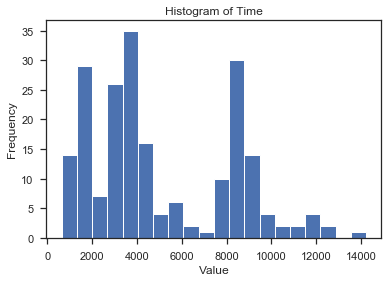

```python
plt.hist(a['Time Moving'],bins=20)
plt.title("Histogram of Time")
plt.xlabel("Value")
plt.ylabel("Frequency")
```

#### Time is not Normally Distributed.

```
AxesSubplot(0.125,0.125;0.775x0.755)
```

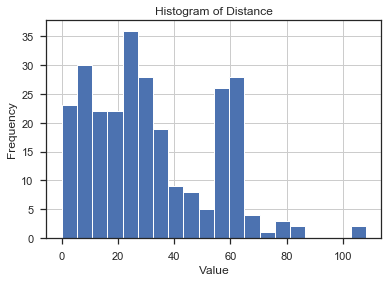

```python
d=strava['distance'].hist(bins=20)
plt.title("Histogram of Distance")
plt.xlabel("Value")
plt.ylabel("Frequency")
print (d)
```

#### Distance is not Normally Distributed but is Right Skewed.

```
AxesSubplot(0.125,0.125;0.775x0.755)
```

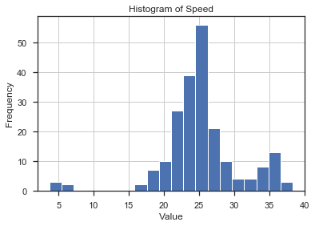

```python
e=a['Average Speed'].hist(bins=20)
plt.title("Histogram of Speed")
plt.xlabel("Value")
plt.ylabel("Frequency")
print (e)
```

#### Average Speed is Normally Distributed.

```
AxesSubplot(0.125,0.125;0.775x0.755)
```

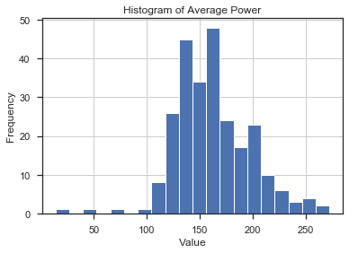

```python
f=strava['average_watts'].hist(bins=20)
plt.title("Histogram of Average Power")
plt.xlabel("Value")
plt.ylabel("Frequency")
print (f)
```

#### Average Power is Normally Distributed.

```
AxesSubplot(0.125,0.125;0.775x0.755)
```

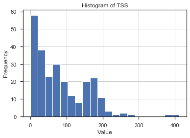

```python
g=cheetah['TSS'].hist(bins=20)
plt.title("Histogram of TSS")
plt.xlabel("Value")
plt.ylabel("Frequency")
print (g)
```

#### TSS is not Normally Distributed but is Right Skewed.

# Question 3

```python
eightvariables = a[['Distance','Time Moving','Average Speed','NP','TSS','Elevation Gain','Average Power','average_heartrate']]
eightvariables.head()
```

|  | Distance | Time Moving | Average Speed | NP | TSS | Elevation Gain | Average Power | average_heartrate |
| --- | --- | --- | --- | --- | --- | --- | --- | --- |
| 2018-01-27 19:39:49+00:00 | 7.5974 | 1053 | 26.0234 | 222.856 | 20.2257 | 77.8 | 153.283 | 120.6 |
| 2018-01-27 20:01:32+00:00 | 38.6279 | 4062 | 34.4380 | 245.365 | 94.5787 | 362.2 | 186.599 | 146.9 |
| 2018-02-05 21:06:42+00:00 | 24.2805 | 3945 | 22.2417 | 253.702 | 98.3269 | 355.8 | 163.264 | 119.3 |
| 2018-02-07 06:59:05+00:00 | 47.0529 | 8159 | 20.7841 | 232.644 | 171.0780 | 815.4 | 148.253 | 124.8 |
| 2018-02-09 19:18:03+00:00 | 59.8128 | 8415 | 25.6585 | 212.726 | 147.7970 | 513.2 | 143.918 | 123.0 |

#### We select the required variables and store the collection in a variable named 'eightvariables'.

```python
correlation = eightvariables.corr(method='pearson')
correlation
```

|  | Distance | Time Moving | Average Speed | NP | TSS | Elevation Gain | Average Power | average_heartrate |
| --- | --- | --- | --- | --- | --- | --- | --- | --- |
| Distance | 1.000000 | 0.933567 | 0.187429 | 0.270715 | 0.922541 | 0.805486 | 0.129226 | 0.114586 |
| Time Moving | 0.933567 | 1.000000 | -0.112951 | 0.034142 | 0.866093 | 0.811409 | -0.119617 | -0.049748 |
| Average Speed | 0.187429 | -0.112951 | 1.000000 | 0.674857 | 0.134054 | -0.016160 | 0.814403 | 0.742388 |
| NP | 0.270715 | 0.034142 | 0.674857 | 1.000000 | 0.432286 | 0.229933 | 0.844487 | 0.593091 |
| TSS | 0.922541 | 0.866093 | 0.134054 | 0.432286 | 1.000000 | 0.828928 | 0.225290 | 0.113775 |
| Elevation Gain | 0.805486 | 0.811409 | -0.016160 | 0.229933 | 0.828928 | 1.000000 | -0.035987 | 0.071553 |
| Average Power | 0.129226 | -0.119617 | 0.814403 | 0.844487 | 0.225290 | -0.035987 | 1.000000 | 0.692413 |
| average_heartrate | 0.114586 | -0.049748 | 0.742388 | 0.593091 | 0.113775 | 0.071553 | 0.692413 | 1.000000 |

#### This is to display the correlation in normal format.

```python
import pandas as pd
import numpy as np

rs = np.random.RandomState(0)
df = pd.DataFrame(rs.rand(10, 10))
corr = correlation.corr()
corr.style.background_gradient(cmap='coolwarm')
```

|  | Distance | Time Moving | Average Speed | NP | TSS | Elevation Gain | Average Power | average_heartrate |
| --- | --- | --- | --- | --- | --- | --- | --- | --- |
| Distance | 1 | 0.992117 | -0.930363 | -0.827977 | 0.977349 | 0.956951 | -0.926831 | -0.95699 |
| Time Moving | 0.992117 | 1 | -0.965271 | -0.869116 | 0.967037 | 0.969486 | -0.959195 | -0.953534 |
| Average Speed | -0.930363 | -0.965271 | 1 | 0.850807 | -0.928473 | -0.966538 | 0.958711 | 0.93118 |
| NP | -0.827977 | -0.869116 | 0.850807 | 1 | -0.718322 | -0.812721 | 0.945565 | 0.772931 |
| TSS | 0.977349 | 0.967037 | -0.928473 | -0.718322 | 1 | 0.958089 | -0.871801 | -0.957828 |
| Elevation Gain | 0.956951 | 0.969486 | -0.966538 | -0.812721 | 0.958089 | 1 | -0.950005 | -0.936092 |
| Average Power | -0.926831 | -0.959195 | 0.958711 | 0.945565 | -0.871801 | -0.950005 | 1 | 0.892489 |
| average_heartrate | -0.95699 | -0.953534 | 0.93118 | 0.772931 | -0.957828 | -0.936092 | 0.892489 | 1 |

#### Here, we have made a correlation matrix with heat colors.

#### Darker the red, more the positive correlation. The strongest positive correlation is between 'Distance' & 'Time Moving'

# Question 4

```python
a['workout_type'].value_counts()
```

```
Ride       155
Race        29
Workout     25
Name: workout_type, dtype: int64
```

#### This gives us the counts for each Workout Type.

```python
wt=a['workout_type']
wt.head()
```

```
2018-01-27 19:39:49+00:00    Ride
2018-01-27 20:01:32+00:00    Race
2018-02-05 21:06:42+00:00    Ride
2018-02-07 06:59:05+00:00    Ride
2018-02-09 19:18:03+00:00    Ride
Name: workout_type, dtype: object
```

#### Then, we assign 'wt' variable the values of variable 'workout_type'.

```python
sliced_df = a[['distance','workout_type','average_temp','average_heartrate','moving_time','TSS']]
```

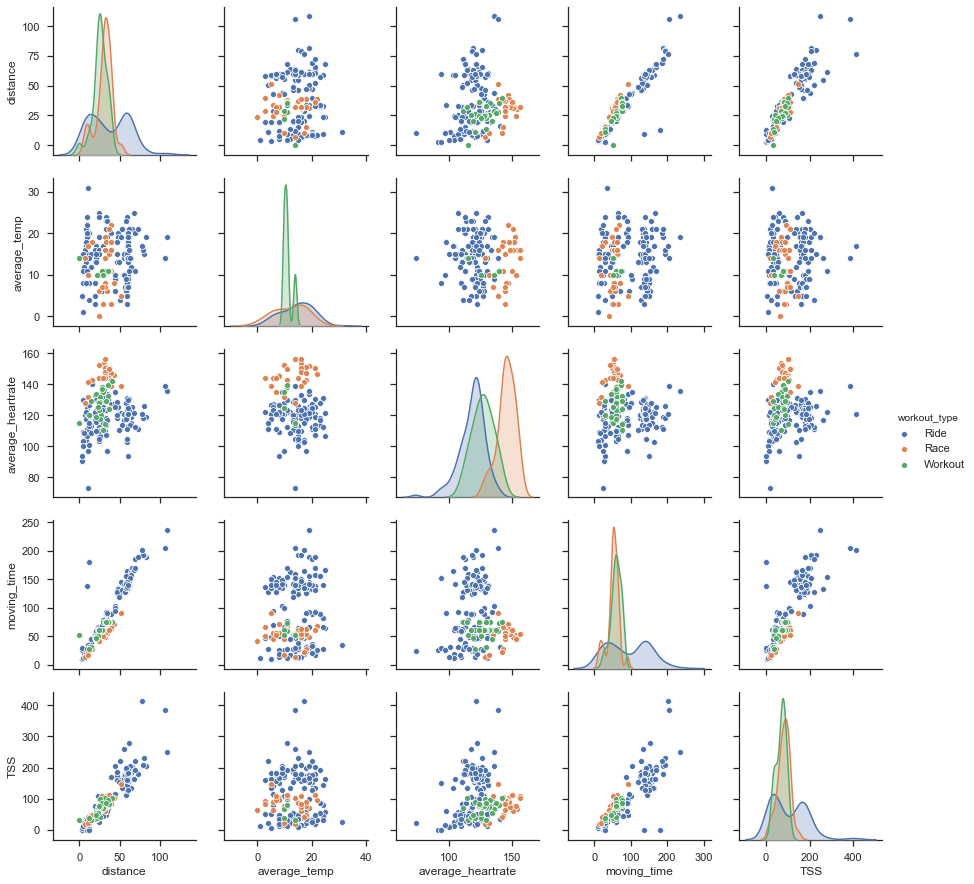

```python
import seaborn as sns
sns.set(style="ticks")
sns.pairplot(sliced_df, hue="workout_type")
```

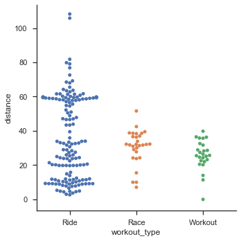

```python
import seaborn as sns
sns.catplot(x='workout_type',y='distance',kind='swarm',data=a)
```

#### Maximum distance covered in Ride followed by Race and then, Workout. (According to Swarm Plot.)

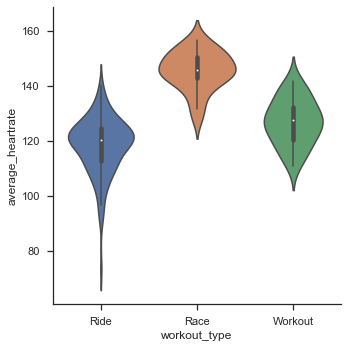

```python
sns.catplot(x='workout_type',y='average_heartrate',kind='violin',data=a)
```

#### Average heartrate is highest in Race, followed by Workout and then, Ride. Also, most varying heartrate is shown in Ride. (According to Violin Plot.)

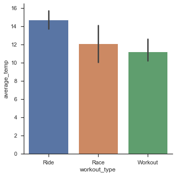

```python
sns.catplot(x='workout_type',y='average_temp',kind='bar',data=a)
```

#### Average Temperature is the highest in Ride, then Race and lastly in Workout. (According to Bar Plot.)

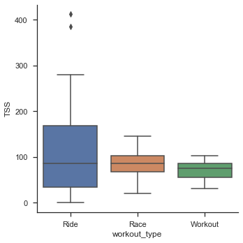

```python
sns.catplot(x='workout_type',y='TSS',kind='box',data=a)
```

#### TSS is the highest in Ride, then Race and lastly in Workout. (According to Box Plot.)

# Portfolio 2 - Predicting Energy Usage

```python
import pandas as pd
import numpy as np
import seaborn as sns
import matplotlib.pyplot as plt
%matplotlib inline
from sklearn.model_selection import train_test_split
from sklearn import linear_model
from sklearn.metrics import r2_score
from sklearn.linear_model import LogisticRegression
from sklearn.metrics import confusion_matrix, accuracy_score
from sklearn.feature_selection import RFE
from sklearn import linear_model
from datetime import datetime
import matplotlib.dates as mdate
```

```python
energy = pd.read_csv("energydata_complete.csv",na_values="?",parse_dates=True)
energy.head()
```

|  | date | Appliances | lights | T1 | RH_1 | T2 | RH_2 | T3 | RH_3 | T4 | ... | T9 | RH_9 | T_out | Press_mm_hg | RH_out | Windspeed | Visibility | Tdewpoint | rv1 | rv2 |
| --- | --- | --- | --- | --- | --- | --- | --- | --- | --- | --- | --- | --- | --- | --- | --- | --- | --- | --- | --- | --- | --- |
| 0 | 2016-01-11 17:00:00 | 60 | 30 | 19.89 | 47.596667 | 19.2 | 44.790000 | 19.79 | 44.730000 | 19.000000 | ... | 17.033333 | 45.53 | 6.600000 | 733.5 | 92.0 | 7.000000 | 63.000000 | 5.3 | 13.275433 | 13.275433 |
| 1 | 2016-01-11 17:10:00 | 60 | 30 | 19.89 | 46.693333 | 19.2 | 44.722500 | 19.79 | 44.790000 | 19.000000 | ... | 17.066667 | 45.56 | 6.483333 | 733.6 | 92.0 | 6.666667 | 59.166667 | 5.2 | 18.606195 | 18.606195 |
| 2 | 2016-01-11 17:20:00 | 50 | 30 | 19.89 | 46.300000 | 19.2 | 44.626667 | 19.79 | 44.933333 | 18.926667 | ... | 17.000000 | 45.50 | 6.366667 | 733.7 | 92.0 | 6.333333 | 55.333333 | 5.1 | 28.642668 | 28.642668 |
| 3 | 2016-01-11 17:30:00 | 50 | 40 | 19.89 | 46.066667 | 19.2 | 44.590000 | 19.79 | 45.000000 | 18.890000 | ... | 17.000000 | 45.40 | 6.250000 | 733.8 | 92.0 | 6.000000 | 51.500000 | 5.0 | 45.410389 | 45.410389 |
| 4 | 2016-01-11 17:40:00 | 60 | 40 | 19.89 | 46.333333 | 19.2 | 44.530000 | 19.79 | 45.000000 | 18.890000 | ... | 17.000000 | 45.40 | 6.133333 | 733.9 | 92.0 | 5.666667 | 47.666667 | 4.9 | 10.084097 | 10.084097 |

5 rows × 29 columns

#### Here, we are reading the energy dataset.

```python
energy.describe()
```

|  | Appliances | lights | T1 | RH_1 | T2 | RH_2 | T3 | RH_3 | T4 | RH_4 | ... | T9 | RH_9 | T_out | Press_mm_hg | RH_out | Windspeed | Visibility | Tdewpoint | rv1 | rv2 |
| --- | --- | --- | --- | --- | --- | --- | --- | --- | --- | --- | --- | --- | --- | --- | --- | --- | --- | --- | --- | --- | --- |
| count | 19735.000000 | 19735.000000 | 19735.000000 | 19735.000000 | 19735.000000 | 19735.000000 | 19735.000000 | 19735.000000 | 19735.000000 | 19735.000000 | ... | 19735.000000 | 19735.000000 | 19735.000000 | 19735.000000 | 19735.000000 | 19735.000000 | 19735.000000 | 19735.000000 | 19735.000000 | 19735.000000 |
| mean | 97.694958 | 3.801875 | 21.686571 | 40.259739 | 20.341219 | 40.420420 | 22.267611 | 39.242500 | 20.855335 | 39.026904 | ... | 19.485828 | 41.552401 | 7.411665 | 755.522602 | 79.750418 | 4.039752 | 38.330834 | 3.760707 | 24.988033 | 24.988033 |
| std | 102.524891 | 7.935988 | 1.606066 | 3.979299 | 2.192974 | 4.069813 | 2.006111 | 3.254576 | 2.042884 | 4.341321 | ... | 2.014712 | 4.151497 | 5.317409 | 7.399441 | 14.901088 | 2.451221 | 11.794719 | 4.194648 | 14.496634 | 14.496634 |
| min | 10.000000 | 0.000000 | 16.790000 | 27.023333 | 16.100000 | 20.463333 | 17.200000 | 28.766667 | 15.100000 | 27.660000 | ... | 14.890000 | 29.166667 | -5.000000 | 729.300000 | 24.000000 | 0.000000 | 1.000000 | -6.600000 | 0.005322 | 0.005322 |
| 25% | 50.000000 | 0.000000 | 20.760000 | 37.333333 | 18.790000 | 37.900000 | 20.790000 | 36.900000 | 19.530000 | 35.530000 | ... | 18.000000 | 38.500000 | 3.666667 | 750.933333 | 70.333333 | 2.000000 | 29.000000 | 0.900000 | 12.497889 | 12.497889 |
| 50% | 60.000000 | 0.000000 | 21.600000 | 39.656667 | 20.000000 | 40.500000 | 22.100000 | 38.530000 | 20.666667 | 38.400000 | ... | 19.390000 | 40.900000 | 6.916667 | 756.100000 | 83.666667 | 3.666667 | 40.000000 | 3.433333 | 24.897653 | 24.897653 |
| 75% | 100.000000 | 0.000000 | 22.600000 | 43.066667 | 21.500000 | 43.260000 | 23.290000 | 41.760000 | 22.100000 | 42.156667 | ... | 20.600000 | 44.338095 | 10.408333 | 760.933333 | 91.666667 | 5.500000 | 40.000000 | 6.566667 | 37.583769 | 37.583769 |
| max | 1080.000000 | 70.000000 | 26.260000 | 63.360000 | 29.856667 | 56.026667 | 29.236000 | 50.163333 | 26.200000 | 51.090000 | ... | 24.500000 | 53.326667 | 26.100000 | 772.300000 | 100.000000 | 14.000000 | 66.000000 | 15.500000 | 49.996530 | 49.996530 |

8 rows × 28 columns

```python
training = pd.read_csv("Training.csv")
training.head()
```

|  | date | Appliances | lights | T1 | RH_1 | T2 | RH_2 | T3 | RH_3 | T4 | ... | Press_mm_hg | RH_out | Windspeed | Visibility | Tdewpoint | rv1 | rv2 | NSM | WeekStatus | Day_of_week |
| --- | --- | --- | --- | --- | --- | --- | --- | --- | --- | --- | --- | --- | --- | --- | --- | --- | --- | --- | --- | --- | --- |
| 0 | 2016-01-11 17:00:00 | 60 | 30 | 19.89 | 47.596667 | 19.2 | 44.790000 | 19.79 | 44.730000 | 19.000000 | ... | 733.5 | 92.0 | 7.000000 | 63.000000 | 5.3 | 13.275433 | 13.275433 | 61200 | Weekday | Monday |
| 1 | 2016-01-11 17:10:00 | 60 | 30 | 19.89 | 46.693333 | 19.2 | 44.722500 | 19.79 | 44.790000 | 19.000000 | ... | 733.6 | 92.0 | 6.666667 | 59.166667 | 5.2 | 18.606195 | 18.606195 | 61800 | Weekday | Monday |
| 2 | 2016-01-11 17:20:00 | 50 | 30 | 19.89 | 46.300000 | 19.2 | 44.626667 | 19.79 | 44.933333 | 18.926667 | ... | 733.7 | 92.0 | 6.333333 | 55.333333 | 5.1 | 28.642668 | 28.642668 | 62400 | Weekday | Monday |
| 3 | 2016-01-11 17:40:00 | 60 | 40 | 19.89 | 46.333333 | 19.2 | 44.530000 | 19.79 | 45.000000 | 18.890000 | ... | 733.9 | 92.0 | 5.666667 | 47.666667 | 4.9 | 10.084097 | 10.084097 | 63600 | Weekday | Monday |
| 4 | 2016-01-11 17:50:00 | 50 | 40 | 19.89 | 46.026667 | 19.2 | 44.500000 | 19.79 | 44.933333 | 18.890000 | ... | 734.0 | 92.0 | 5.333333 | 43.833333 | 4.8 | 44.919484 | 44.919484 | 64200 | Weekday | Monday |

5 rows × 32 columns

#### Reading the Training Data

```python
training.shape
```

```
(14803, 32)
```

```python
testing = pd.read_csv("Testing.csv")
testing.head()
```

|  | date | Appliances | lights | T1 | RH_1 | T2 | RH_2 | T3 | RH_3 | T4 | ... | Press_mm_hg | RH_out | Windspeed | Visibility | Tdewpoint | rv1 | rv2 | NSM | WeekStatus | Day_of_week |
| --- | --- | --- | --- | --- | --- | --- | --- | --- | --- | --- | --- | --- | --- | --- | --- | --- | --- | --- | --- | --- | --- |
| 0 | 2016-01-11 17:30:00 | 50 | 40 | 19.890000 | 46.066667 | 19.200000 | 44.590000 | 19.79 | 45.000000 | 18.89 | ... | 733.800000 | 92.000000 | 6.000000 | 51.5 | 5.000000 | 45.410389 | 45.410389 | 63000 | Weekday | Monday |
| 1 | 2016-01-11 18:00:00 | 60 | 50 | 19.890000 | 45.766667 | 19.200000 | 44.500000 | 19.79 | 44.900000 | 18.89 | ... | 734.100000 | 92.000000 | 5.000000 | 40.0 | 4.700000 | 47.233763 | 47.233763 | 64800 | Weekday | Monday |
| 2 | 2016-01-11 18:40:00 | 230 | 70 | 19.926667 | 45.863333 | 19.356667 | 44.400000 | 19.79 | 44.900000 | 18.89 | ... | 734.366667 | 91.333333 | 5.666667 | 40.0 | 4.633333 | 10.298729 | 10.298729 | 67200 | Weekday | Monday |
| 3 | 2016-01-11 18:50:00 | 580 | 60 | 20.066667 | 46.396667 | 19.426667 | 44.400000 | 19.79 | 44.826667 | 19.00 | ... | 734.433333 | 91.166667 | 5.833333 | 40.0 | 4.616667 | 8.827838 | 8.827838 | 67800 | Weekday | Monday |
| 4 | 2016-01-11 19:30:00 | 100 | 10 | 20.566667 | 53.893333 | 20.033333 | 46.756667 | 20.10 | 48.466667 | 19.00 | ... | 734.850000 | 89.500000 | 6.000000 | 40.0 | 4.350000 | 24.884962 | 24.884962 | 70200 | Weekday | Monday |

5 rows × 32 columns

#### Reading the Test Data

```python
testing.shape
```

```
(4932, 32)
```

```python
energy.corr()
```

|  | Appliances | lights | T1 | RH_1 | T2 | RH_2 | T3 | RH_3 | T4 | RH_4 | ... | T9 | RH_9 | T_out | Press_mm_hg | RH_out | Windspeed | Visibility | Tdewpoint | rv1 | rv2 |
| --- | --- | --- | --- | --- | --- | --- | --- | --- | --- | --- | --- | --- | --- | --- | --- | --- | --- | --- | --- | --- | --- |
| Appliances | 1.000000 | 0.197278 | 0.055447 | 0.086031 | 0.120073 | -0.060465 | 0.085060 | 0.036292 | 0.040281 | 0.016965 | ... | 0.010010 | -0.051462 | 0.099155 | -0.034885 | -0.152282 | 0.087122 | 0.000230 | 0.015353 | -0.011145 | -0.011145 |
| lights | 0.197278 | 1.000000 | -0.023528 | 0.106968 | -0.005622 | 0.050985 | -0.097393 | 0.131161 | -0.008859 | 0.114936 | ... | -0.157592 | -0.008766 | -0.074424 | -0.010576 | 0.068543 | 0.060281 | 0.020038 | -0.036322 | 0.000521 | 0.000521 |
| T1 | 0.055447 | -0.023528 | 1.000000 | 0.164006 | 0.836834 | -0.002509 | 0.892402 | -0.028550 | 0.877001 | 0.097861 | ... | 0.844777 | 0.071756 | 0.682846 | -0.150574 | -0.345481 | -0.087654 | -0.076210 | 0.571309 | -0.006203 | -0.006203 |
| RH_1 | 0.086031 | 0.106968 | 0.164006 | 1.000000 | 0.269839 | 0.797535 | 0.253230 | 0.844677 | 0.106180 | 0.880359 | ... | 0.115263 | 0.764001 | 0.340767 | -0.293957 | 0.274126 | 0.204932 | -0.021057 | 0.639106 | -0.000699 | -0.000699 |
| T2 | 0.120073 | -0.005622 | 0.836834 | 0.269839 | 1.000000 | -0.165610 | 0.735245 | 0.121497 | 0.762066 | 0.231563 | ... | 0.675535 | 0.157346 | 0.792255 | -0.133028 | -0.505291 | 0.052495 | -0.069721 | 0.582602 | -0.011087 | -0.011087 |
| RH_2 | -0.060465 | 0.050985 | -0.002509 | 0.797535 | -0.165610 | 1.000000 | 0.137319 | 0.678326 | -0.047304 | 0.721435 | ... | 0.054544 | 0.676467 | 0.033674 | -0.255646 | 0.584911 | 0.069190 | -0.005368 | 0.499152 | 0.006275 | 0.006275 |
| T3 | 0.085060 | -0.097393 | 0.892402 | 0.253230 | 0.735245 | 0.137319 | 1.000000 | -0.011234 | 0.852778 | 0.122737 | ... | 0.901324 | 0.134602 | 0.699417 | -0.189974 | -0.281718 | -0.100776 | -0.102310 | 0.645886 | -0.005194 | -0.005194 |
| RH_3 | 0.036292 | 0.131161 | -0.028550 | 0.844677 | 0.121497 | 0.678326 | -0.011234 | 1.000000 | -0.140457 | 0.898978 | ... | -0.195270 | 0.833538 | 0.118207 | -0.233274 | 0.356192 | 0.263188 | 0.017041 | 0.414387 | -0.000477 | -0.000477 |
| T4 | 0.040281 | -0.008859 | 0.877001 | 0.106180 | 0.762066 | -0.047304 | 0.852778 | -0.140457 | 1.000000 | -0.048650 | ... | 0.889439 | -0.025549 | 0.663478 | -0.075292 | -0.388602 | -0.185747 | -0.104768 | 0.519471 | -0.001815 | -0.001815 |
| RH_4 | 0.016965 | 0.114936 | 0.097861 | 0.880359 | 0.231563 | 0.721435 | 0.122737 | 0.898978 | -0.048650 | 1.000000 | ... | -0.044518 | 0.856591 | 0.293289 | -0.250748 | 0.336813 | 0.300192 | 0.002636 | 0.616509 | -0.001787 | -0.001787 |
| T5 | 0.019760 | -0.078745 | 0.885247 | 0.205797 | 0.720550 | 0.110409 | 0.888169 | -0.050062 | 0.871813 | 0.091812 | ... | 0.911055 | 0.072308 | 0.651321 | -0.170999 | -0.273953 | -0.145011 | -0.084164 | 0.588362 | -0.005490 | -0.005490 |
| RH_5 | 0.006955 | 0.141233 | -0.014782 | 0.303258 | 0.029595 | 0.250271 | -0.066355 | 0.375422 | -0.076489 | 0.352591 | ... | -0.138509 | 0.272197 | -0.053126 | -0.119327 | 0.185941 | 0.082044 | -0.013133 | 0.078175 | -0.011056 | -0.011056 |
| T6 | 0.117638 | -0.079029 | 0.654769 | 0.316141 | 0.801186 | -0.009670 | 0.686882 | 0.076833 | 0.652350 | 0.259047 | ... | 0.667177 | 0.184424 | 0.974787 | -0.141643 | -0.569119 | 0.169185 | -0.081313 | 0.764242 | -0.015086 | -0.015086 |
| RH_6 | -0.083178 | 0.153756 | -0.615045 | 0.245126 | -0.580372 | 0.389933 | -0.647672 | 0.514912 | -0.703149 | 0.392178 | ... | -0.738940 | 0.391943 | -0.641572 | -0.065814 | 0.718587 | 0.098317 | 0.108705 | -0.260417 | 0.011671 | 0.011671 |
| T7 | 0.025801 | -0.135347 | 0.838705 | 0.021397 | 0.663660 | -0.051422 | 0.847374 | -0.250090 | 0.877763 | -0.131204 | ... | 0.944776 | -0.077690 | 0.631293 | -0.097724 | -0.411213 | -0.185892 | -0.110089 | 0.466625 | -0.003900 | -0.003900 |
| RH_7 | -0.055642 | 0.035069 | 0.135182 | 0.801122 | 0.229212 | 0.690584 | 0.172624 | 0.832685 | 0.043527 | 0.894301 | ... | 0.028055 | 0.858686 | 0.294199 | -0.265850 | 0.378519 | 0.212979 | -0.007184 | 0.641857 | 0.001820 | 0.001820 |
| T8 | 0.039572 | -0.071458 | 0.825413 | -0.030053 | 0.578191 | -0.041023 | 0.795283 | -0.283228 | 0.796256 | -0.167066 | ... | 0.869338 | -0.156820 | 0.502842 | -0.162855 | -0.300438 | -0.218876 | -0.060098 | 0.391810 | -0.003210 | -0.003210 |
| RH_8 | -0.094039 | 0.012915 | -0.006441 | 0.736196 | 0.068534 | 0.679777 | 0.044427 | 0.828822 | -0.095192 | 0.847259 | ... | -0.113014 | 0.855812 | 0.117141 | -0.225591 | 0.487355 | 0.202380 | 0.046178 | 0.501775 | 0.004480 | 0.004480 |
| T9 | 0.010010 | -0.157592 | 0.844777 | 0.115263 | 0.675535 | 0.054544 | 0.901324 | -0.195270 | 0.889439 | -0.044518 | ... | 1.000000 | -0.008683 | 0.668220 | -0.156828 | -0.318848 | -0.177756 | -0.103915 | 0.581483 | -0.001227 | -0.001227 |
| RH_9 | -0.051462 | -0.008766 | 0.071756 | 0.764001 | 0.157346 | 0.676467 | 0.134602 | 0.833538 | -0.025549 | 0.856591 | ... | -0.008683 | 1.000000 | 0.223270 | -0.183739 | 0.359377 | 0.238655 | 0.008667 | 0.540328 | -0.002955 | -0.002955 |
| T_out | 0.099155 | -0.074424 | 0.682846 | 0.340767 | 0.792255 | 0.033674 | 0.699417 | 0.118207 | 0.663478 | 0.293289 | ... | 0.668220 | 0.223270 | 1.000000 | -0.143249 | -0.574197 | 0.192936 | -0.077367 | 0.790661 | -0.015216 | -0.015216 |
| Press_mm_hg | -0.034885 | -0.010576 | -0.150574 | -0.293957 | -0.133028 | -0.255646 | -0.189974 | -0.233274 | -0.075292 | -0.250748 | ... | -0.156828 | -0.183739 | -0.143249 | 1.000000 | -0.092017 | -0.235032 | 0.040315 | -0.244098 | 0.000699 | 0.000699 |
| RH_out | -0.152282 | 0.068543 | -0.345481 | 0.274126 | -0.505291 | 0.584911 | -0.281718 | 0.356192 | -0.388602 | 0.336813 | ... | -0.318848 | 0.359377 | -0.574197 | -0.092017 | 1.000000 | -0.176458 | 0.083125 | 0.036506 | 0.020441 | 0.020441 |
| Windspeed | 0.087122 | 0.060281 | -0.087654 | 0.204932 | 0.052495 | 0.069190 | -0.100776 | 0.263188 | -0.185747 | 0.300192 | ... | -0.177756 | 0.238655 | 0.192936 | -0.235032 | -0.176458 | 1.000000 | -0.007516 | 0.125972 | -0.011342 | -0.011342 |
| Visibility | 0.000230 | 0.020038 | -0.076210 | -0.021057 | -0.069721 | -0.005368 | -0.102310 | 0.017041 | -0.104768 | 0.002636 | ... | -0.103915 | 0.008667 | -0.077367 | 0.040315 | 0.083125 | -0.007516 | 1.000000 | -0.042190 | -0.005889 | -0.005889 |
| Tdewpoint | 0.015353 | -0.036322 | 0.571309 | 0.639106 | 0.582602 | 0.499152 | 0.645886 | 0.414387 | 0.519471 | 0.616509 | ... | 0.581483 | 0.540328 | 0.790661 | -0.244098 | 0.036506 | 0.125972 | -0.042190 | 1.000000 | -0.003943 | -0.003943 |
| rv1 | -0.011145 | 0.000521 | -0.006203 | -0.000699 | -0.011087 | 0.006275 | -0.005194 | -0.000477 | -0.001815 | -0.001787 | ... | -0.001227 | -0.002955 | -0.015216 | 0.000699 | 0.020441 | -0.011342 | -0.005889 | -0.003943 | 1.000000 | 1.000000 |
| rv2 | -0.011145 | 0.000521 | -0.006203 | -0.000699 | -0.011087 | 0.006275 | -0.005194 | -0.000477 | -0.001815 | -0.001787 | ... | -0.001227 | -0.002955 | -0.015216 | 0.000699 | 0.020441 | -0.011342 | -0.005889 | -0.003943 | 1.000000 | 1.000000 |

28 rows × 28 columns

#### Showing the Correlation Matrix of the data

### Pair Plot

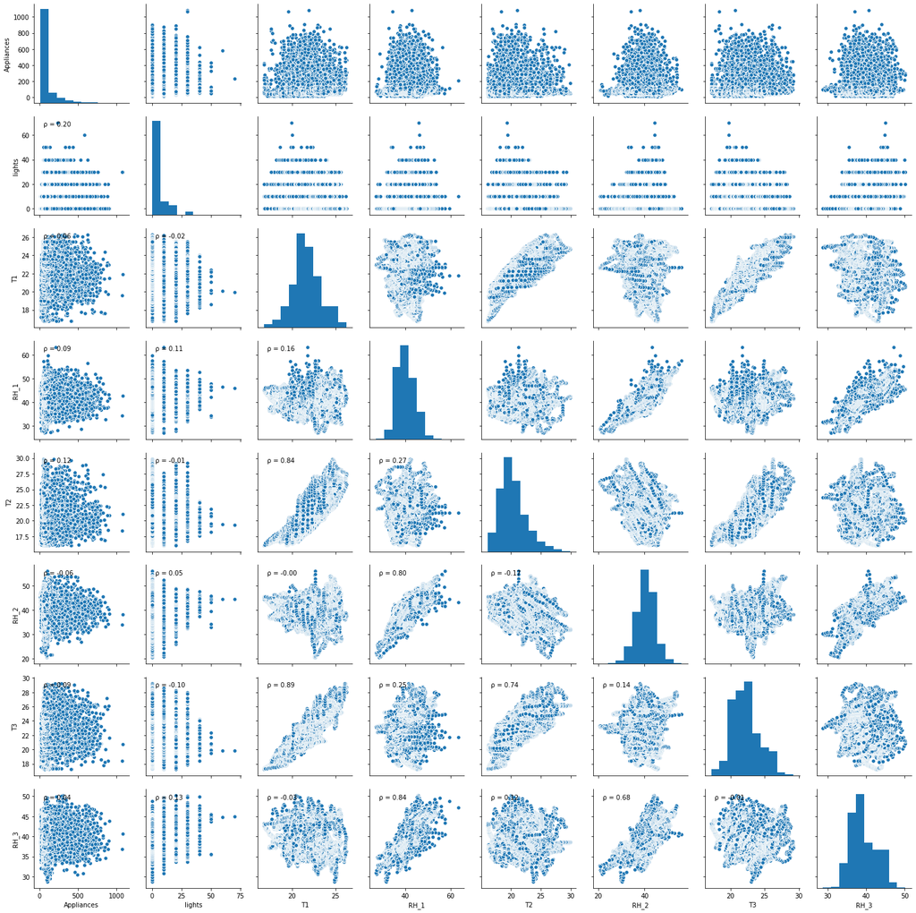

```python
from scipy.stats import pearsonr
import matplotlib.pyplot as plt

def corrfunc(x,y, ax=None, **kws):
    """Plot the correlation coefficient in the top left hand corner of a plot."""
    r, _ = pearsonr(x, y)
    ax = ax or plt.gca()
    # Unicode for lowercase rho (ρ)
    rho = '\u03C1'
    ax.annotate(f'{rho} = {r:.2f}', xy=(.1, .9), xycoords=ax.transAxes)

import matplotlib.pyplot as plt
import numpy as np
import pandas as pd
import seaborn as sns
plt.figure()
g=sns.pairplot(data=energy[["Appliances","lights","T1","RH_1","T2","RH_2","T3","RH_3"]], dropna=True)
g.map_lower(corrfunc)
plt.show()
```

```python
dfbb=energy[["Appliances","lights","T1","RH_1","T2","RH_2","T3","RH_3"]]
```

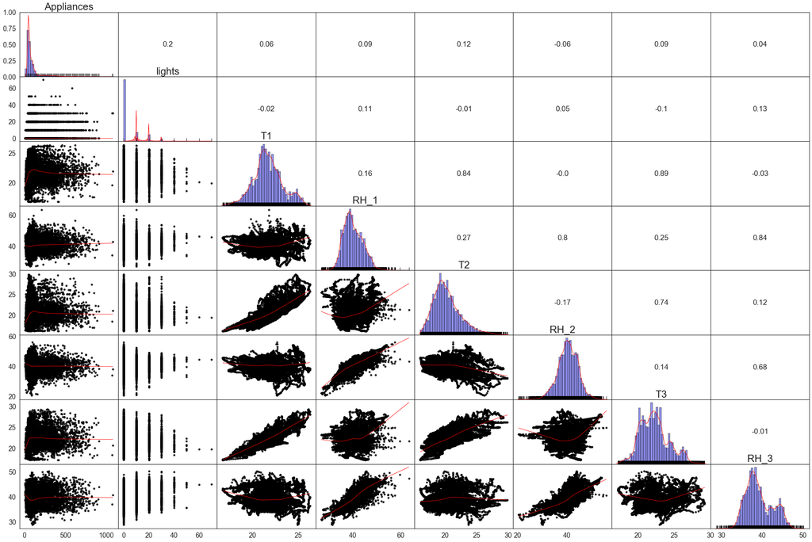

```python
import matplotlib.pyplot as plt
from scipy import stats
import seaborn as sns
import numpy as np

def corrdot(*args, **kwargs):
    corr_r = args[0].corr(args[1], 'pearson')
    corr_text = round(corr_r, 2)
    ax = plt.gca()
    ax.annotate(corr_text, [.5, .5,],  xycoords="axes fraction",
                ha='center', va='center')



sns.set(style='white', font_scale=1.6)

g = sns.PairGrid(dfbb, aspect=1.5, diag_sharey=False, despine=False)
g.map_lower(sns.regplot, lowess=True, ci=False,
            line_kws={'color': 'red', 'lw': 1},
            scatter_kws={'color': 'black', 's': 20})
g.map_diag(sns.distplot, color='black',
           kde_kws={'color': 'red', 'cut': 0.7, 'lw': 1},
           hist_kws={'histtype': 'bar', 'lw': 2,
                     'edgecolor': 'k', 'facecolor':'blue'})
g.map_diag(sns.rugplot, color='black')
g.map_upper(corrdot)
g.fig.subplots_adjust(wspace=0, hspace=0)

for ax in g.axes.flatten():
    ax.set_ylabel('')
    ax.set_xlabel('')

for ax, col in zip(np.diag(g.axes), dfbb.columns):
    ax.set_title(col, y=0.82, fontsize=26)
```

```python
energy['date']=pd.to_datetime(energy['date'])
training['date']=pd.to_datetime(training['date'])
testing['date']=pd.to_datetime(testing['date'])
```

[output not shown]

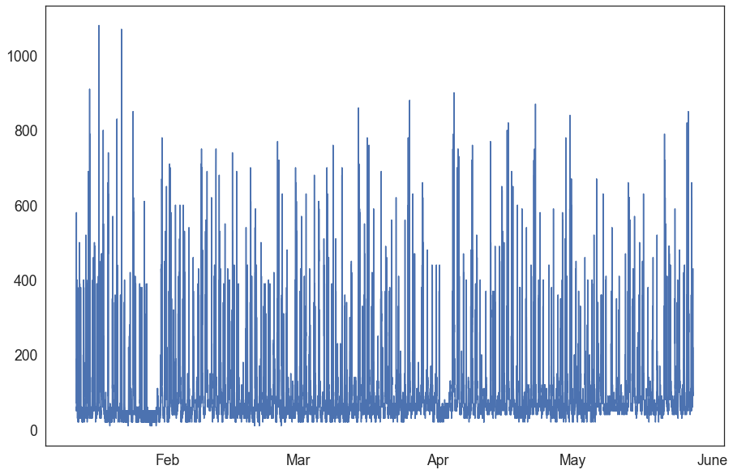

```python
plt.figure(figsize=(15,10))

plt.plot(energy["date"], energy["Appliances"])
plt.gca().xaxis.set_major_locator(mdate.MonthLocator())
plt.gca().set_xticklabels(["Feb","Mar","Apr","May","June"])
```

#### Plotting Dates (Months) with 'Appliances Wh'

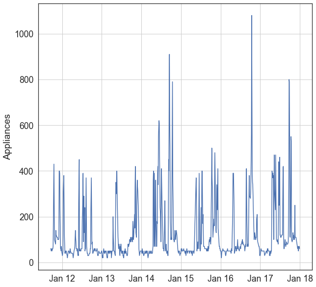

```python
week = training["date"].dt.week
first_week = training[week == min(week)]
first_week
plt.figure(figsize=(10,10))
plt.plot(first_week['date'],first_week['Appliances'])
plt.gca().xaxis.set_major_locator(mdate.DayLocator())
plt.gca().xaxis.set_major_formatter(mdate.DateFormatter("Jan %d"))
plt.ylabel("Appliances")
plt.grid(True)
```

#### Comparing 1 week consumption with 'Appliances Wh'.

```python
dfbb=energy[["Appliances","lights","T1","RH_1","T2","RH_2","T3","RH_3"]]
dfbb
```

|  | Appliances | lights | T1 | RH_1 | T2 | RH_2 | T3 | RH_3 |
| --- | --- | --- | --- | --- | --- | --- | --- | --- |
| 0 | 60 | 30 | 19.890000 | 47.596667 | 19.200000 | 44.790000 | 19.790000 | 44.730000 |
| 1 | 60 | 30 | 19.890000 | 46.693333 | 19.200000 | 44.722500 | 19.790000 | 44.790000 |
| 2 | 50 | 30 | 19.890000 | 46.300000 | 19.200000 | 44.626667 | 19.790000 | 44.933333 |
| 3 | 50 | 40 | 19.890000 | 46.066667 | 19.200000 | 44.590000 | 19.790000 | 45.000000 |
| 4 | 60 | 40 | 19.890000 | 46.333333 | 19.200000 | 44.530000 | 19.790000 | 45.000000 |
| ... | ... | ... | ... | ... | ... | ... | ... | ... |
| 19730 | 100 | 0 | 25.566667 | 46.560000 | 25.890000 | 42.025714 | 27.200000 | 41.163333 |
| 19731 | 90 | 0 | 25.500000 | 46.500000 | 25.754000 | 42.080000 | 27.133333 | 41.223333 |
| 19732 | 270 | 10 | 25.500000 | 46.596667 | 25.628571 | 42.768571 | 27.050000 | 41.690000 |
| 19733 | 420 | 10 | 25.500000 | 46.990000 | 25.414000 | 43.036000 | 26.890000 | 41.290000 |
| 19734 | 430 | 10 | 25.500000 | 46.600000 | 25.264286 | 42.971429 | 26.823333 | 41.156667 |

19735 rows × 8 columns

```python
reg = linear_model.LinearRegression()
X_train = training.loc[:,'lights':'rv2']
y_train = training['Appliances']
reg.fit(X_train, y_train)
print("y = x *", reg.coef_, "+", reg.intercept_)
```

```
y = x * [ 1.94230390e+00 -2.40341397e+00  1.51385291e+01 -1.75319924e+01
 -1.38312029e+01  2.70553013e+01  5.47766249e+00 -2.83799210e+00
 -1.99627755e-01 -1.11479337e+00  1.73873984e-01  6.94784663e+00
  3.31249351e-01  1.93219597e+00 -1.78244526e+00  8.88733259e+00
 -4.56785734e+00 -1.58988788e+01 -1.06717367e+00 -1.02453635e+01
  1.79371342e-01 -1.11984275e+00  1.75289214e+00  1.33556832e-01
  5.41219014e+00 -2.51078307e-02 -2.51078307e-02] + 15.002183915872777
```

```python
y_pred_train = reg.predict(X_train)
mse = ((np.array(y_train)-y_pred_train)**2).sum()/len(y_train) # Mean Square Error should be 0
r2 = r2_score(y_train, y_pred_train) # R- Square Value should be 1
print("MSE:", mse)
print("R Squared:", r2)
```

```
MSE: 8781.372915445201
R Squared: 0.16944419268927147
```

#### For MSE, the value seems too large & for R^2, the value seems too small.

#### Therefore, it is safe to say that linear regression is not a good fit for this data since it's not giving perfect results.

```python
reg = linear_model.LinearRegression()
X_test = testing.loc[:,'lights':'rv2']
y_test = testing['Appliances']
reg.fit(X_test, y_test)
print("y = x *", reg.coef_, "+", reg.intercept_)
```

```
y = x * [ 2.11109979e+00  4.60272467e+00  1.51935503e+01 -1.80521967e+01
 -1.24086568e+01  2.05431777e+01  3.39880086e+00 -5.22767726e+00
 -1.48379239e-01  3.19730062e+00  4.40849629e-02  7.57002323e+00
  1.54090720e-01  1.35621028e+00 -1.02555086e+00  5.64393661e+00
 -4.87255741e+00 -1.56750161e+01 -4.84387392e-01 -1.00125999e+01
 -7.85646203e-03 -8.72868346e-01  1.55803547e+00  2.10648059e-01
  3.88809365e+00 -1.10836147e-02 -1.10836147e-02] + 178.14594386251002
```

```python
y_predicted_test = reg.predict(X_test)
mse = ((np.array(y_test)-y_predicted_test)**2).sum()/len(y_test) # Mean Square Error should be 0
r2 = r2_score(y_test, y_predicted_test) # R- Square Value should be 1
print("MSE:", mse)
print("R Squared:", r2)
```

```
MSE: 8725.760028414785
R Squared: 0.15475344984745565
```

#### Here, for MSE, the value seems too large & for R^2, the value seems too small.

#### Therefore, again, we can say that linear regression is not a good fit for this data since it's not giving perfect results.

```python
rfe=RFE(estimator=reg,n_features_to_select=30,step=1)
rfe.fit(X_test,y_test)
```

```
RFE(estimator=LinearRegression(copy_X=True, fit_intercept=True, n_jobs=None,
                               normalize=False),
    n_features_to_select=30, step=1, verbose=0)
```

```python
y_predicted_test = rfe.predict(X_test)
mse = ((np.array(y_test)-y_predicted_test)**2).sum()/len(y_test) # Mean Square Error should be 0
r2 = r2_score(y_test, y_predicted_test) # R- Square Value should be 1
print("MSE:", mse)
print("R Squared:", r2)
```

```
MSE: 8725.760028414785
R Squared: 0.15475344984745565
```

#### Linear Regression won't be a good fit because values of MSE & R^2 are almost similar for Training data, Test data & RFE.

### Histogram

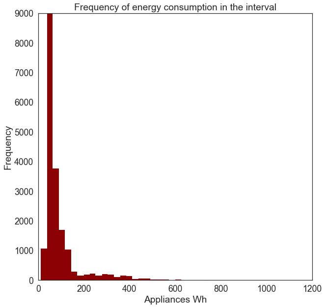

```python
plt.figure(figsize=(10,10))
plt.hist('Appliances',bins=40,histtype='stepfilled',color='darkred',data=energy)
plt.xlim(0,1200)
plt.ylim(0,9000)
plt.xlabel("Appliances Wh")
plt.ylabel("Frequency")
plt.title("Frequency of energy consumption in the interval")
```

#### Histogram to compare 'Frequency' & 'Appliances Wh'. We can observe energy consumption frequency in the given interval. It shows highest consumption at approximately 60 'Appliances Wh'.

### Boxplot

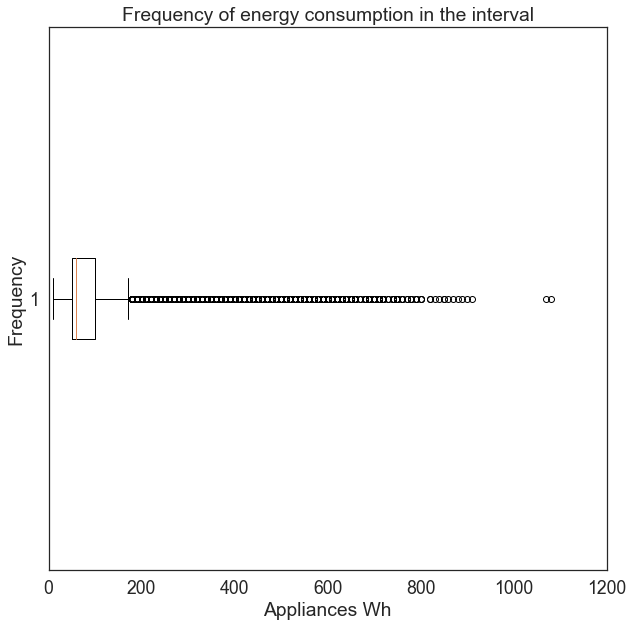

```python
plt.figure(figsize=(10,10))
plt.boxplot('Appliances',data=energy,vert=False)
plt.xlim(0,1200)
plt.xlabel("Appliances Wh")
plt.ylabel("Frequency")
plt.title("Frequency of energy consumption in the interval")
```

#### Boxplot to compare 'Frequency' & 'Appliances Wh'. It has multiple outliers in the data. We can see the median to be around 60.

```python
diff=y_test-y_predicted_test
```

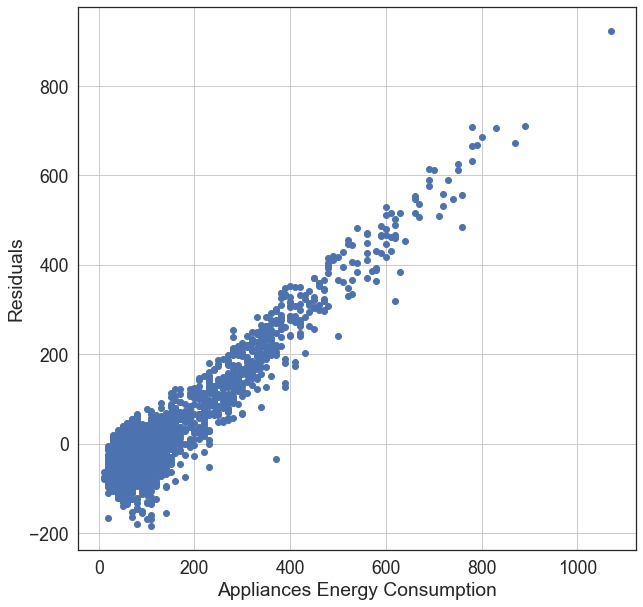

```python
plt.figure(figsize = (10,10))
plt.scatter(testing.Appliances,diff)
plt.xlabel('Appliances Energy Consumption')
plt.ylabel('Residuals')
plt.grid(True)
```

#### Residuals vs Energy Consumption for the lm model.

#### We can say that there is high dispersion & we need to discover the more important features rather than including everything.

### Heatmap

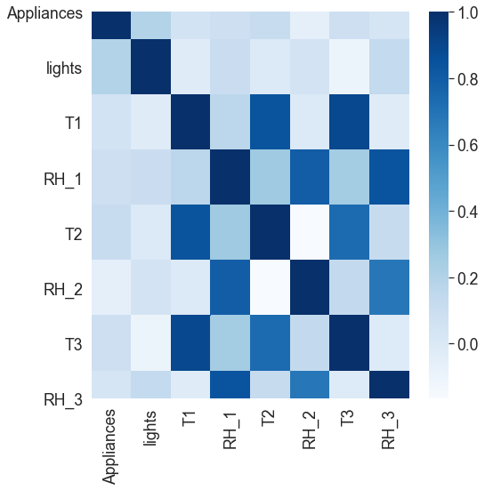

```python
dfb=energy[["Appliances","lights","T1","RH_1","T2","RH_2","T3","RH_3"]]
# Calculate correlations
corr = dfb.corr()
fig, ax = plt.subplots(figsize=(8,8))
# Heatmap
sns.heatmap(corr, cmap="Blues")
```

# Discovering Important Features

```python
line=linear_model.LinearRegression()
```

```
Optimal number of features : 8
```

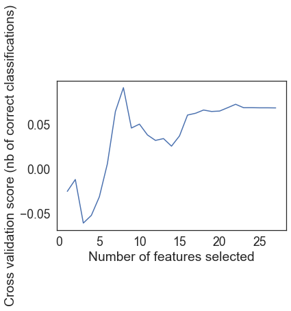

```python
from sklearn.model_selection import StratifiedKFold
from sklearn.feature_selection import RFECV
from sklearn.datasets import make_classification

# classifications
rfecv = RFECV(estimator=line, step=1, cv=StratifiedKFold(2),
              scoring='r2')
rfecv.fit(X_train, y_train)

print("Optimal number of features : %d" % rfecv.n_features_)

# Plot number of features VS. cross-validation scores
plt.figure()
plt.xlabel("Number of features selected")
plt.ylabel("Cross validation score (nb of correct classifications)")
plt.plot(range(1, len(rfecv.grid_scores_) + 1), rfecv.grid_scores_)
plt.show()
```

#### Only 8 Features are the most important for our model.

### Feature Ranking

```python
rfecv.ranking_
```

```
array([ 5,  6,  1,  1,  1,  1,  1,  4, 15, 11, 17,  2, 14,  9,  8,  1,  1,
        1, 12,  3, 16, 13,  7, 18, 10, 19, 20])
```

```python
col=iter(energy.columns.values)
col
```

```
<iterator at 0x1a2c2919e8>
```

```python
from sklearn.ensemble import RandomForestClassifier

regressor = RandomForestClassifier(n_estimators=400, random_state=0, n_jobs=-1)
regressor.fit(X_train, y_train)
y_pred = regressor.predict(X_test)
```

```python
from sklearn import metrics

print('Mean Absolute Error:', metrics.mean_absolute_error(y_test, y_pred))
print('Mean Squared Error:', metrics.mean_squared_error(y_test, y_pred))
print('Root Mean Squared Error:', np.sqrt(metrics.mean_squared_error(y_test, y_pred)))
```

```
Mean Absolute Error: 30.67315490673155
Mean Squared Error: 6258.8807785888075
Root Mean Squared Error: 79.11308854158588
```

### Conclusion:

### Model not showing proper fitting so we need to tune it for better fitting. We also notice that some feaures are not as useful comparitively and they can be removed in order to improve our model.

# Portfolio 3 - Clustering Visualisation

K-means clustering is one of the simplest and popular unsupervised learning algorithms. Typically, unsupervised algorithms make inferences from datasets using only input vectors without referring to known, or labelled, outcomes. This notebook illustrates the process of K-means clustering by generating some random clusters of data and then showing the iterations of the algorithm as random cluster means are updated.

We first generate random data around 4 centers.

```python
import numpy as np
import pandas as pd
from matplotlib import pyplot as plt
%matplotlib inline
```

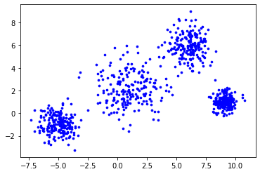

```python
center_1 = np.array([1,2])
center_2 = np.array([6,6])
center_3 = np.array([9,1])
center_4 = np.array([-5,-1])

np.random.seed(5)
data_1 = np.random.randn(200,2) * 1.5 + center_1
data_2 = np.random.randn(200,2) * 1 + center_2
data_3 = np.random.randn(200,2) * 0.5 + center_3
data_4 = np.random.randn(200,2) * 0.8 + center_4

data = np.concatenate((data_1, data_2, data_3, data_4), axis = 0)

plt.scatter(data[:,0], data[:,1], s=7, c='b')
plt.show()
```

#### Generating the random data and centering it to the four centers, each with a different variance.

```python
data
```

```
array([[ 1.66184123,  1.50369477],
       [ 4.64615678,  1.62186181],
       [ 1.16441476,  4.37372168],
       ...,
       [-5.94762563,  0.05925507],
       [-5.5282781 , -0.16683908],
       [-5.02162618, -0.15647292]])
```

```python
data[0]
```

```
array([1.66184123, 1.50369477])
```

```python
data.shape
```

```
(800, 2)
```

#### it depicts 2-Dimensional Data.

## 1. Generate random cluster centres

You need to generate four random centres.

This part of portfolio should contain at least:

- The number of clusters `k` is set to 4;
- Generate random centres via `centres = np.random.randn(k,c)*std + mean` where `std` and `mean` are the standard deviation and mean of the data. `c` represents the number of features in the data. Set the random seed to 6.
- Color the generated centers with `green`, `blue`, `yellow`, and `cyan`. Set the edgecolors to `red`.

```python
k=4
mean=data.mean()
print(mean)
```

```
2.3897478180960845
```

#### The number of clusters 'k' is set to 4.

```python
std=np.std(data)
print(std)
```

```
4.319440166126304
```

```python
np.random.seed(6)
centres = np.random.randn(k,2)*std + mean  #Generate random centres via centres = np.random.randn(k,c)*std + mean
print(centres)
```

```
[[ 1.0430169   5.53863665]
 [ 3.33061168 -1.4938254 ]
 [-8.35175241  6.33448312]
 [ 7.25803215 -4.15028729]]
```

```python
centres.shape
```

```
(4, 2)
```

```python
centres[0]
```

```
array([1.0430169 , 5.53863665])
```

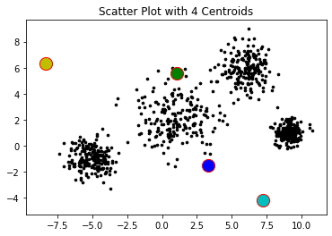

```python
def plotting():
    plt.scatter(data[:,0], data[:,1], s=7, c='k')
    col=['g','b','y','c']
    for i in range(4):
        color=col[i]
        plt.scatter(centres[i][0],centres[i][1], s=200, c=color, edgecolors='red')
        plt.title("Scatter Plot with 4 Centroids")
plotting()
```

#### We have placed four centroids on the the data randomly using different colours.

## 2. Visualise the clustering results in each iteration

You need to implement the process of k-means clustering. Implement each iteration as a seperate cell, assigning each data point to the closest centre, then updating the cluster centres based on the data, then plot the new clusters.

```python
clusters=np.zeros(len(data))
clusters.shape
```

```
(800,)
```

### Finding Distances

```python
def distance(point, centroid, ax=1):
    return np.linalg.norm(point - centroid, axis=ax)
```

### Cluster Finding Function

```python
def finding_cluster():
    for i in range(len(data)):
        distances = distance(data[i],centres)
        cluster = np.argmin(distances)
        clusters[i] = cluster
```

```python
finding_cluster()
```

### Centre Finding Function

```python
def find_centres():
    for r in range(k):
        pts=[data[j] for j in range(len(data)) if clusters[j]==r]
        centres[r]=np.mean(pts,axis=0)
```

### First Attempt

```python
find_centres()
centres
```

```
array([[ 3.99620775,  4.82013001],
       [-1.08109426, -0.14715591],
       [-5.54024032, -0.68960389],
       [ 9.09422694,  1.02197195]])
```

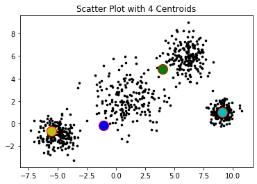

```python
plotting()
```

#### Somewhat close results observed but not perfectly in centre.

### Second Attempt

```python
finding_cluster()
find_centres()
centres
```

```
array([[ 4.90132371,  5.15030358],
       [ 0.24633035,  1.5433697 ],
       [-5.0796739 , -0.95753889],
       [ 9.05236058,  1.0794625 ]])
```

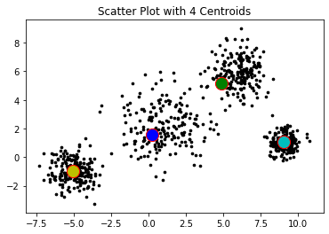

```python
plotting()
```

#### Better results observed compared to previous iteration.

### Third Attempt

```python
finding_cluster()
find_centres()
centres
```

```
array([[ 5.76438788,  5.71757292],
       [ 0.77137496,  2.03200622],
       [-5.05717014, -0.94967031],
       [ 9.063639  ,  1.04633907]])
```

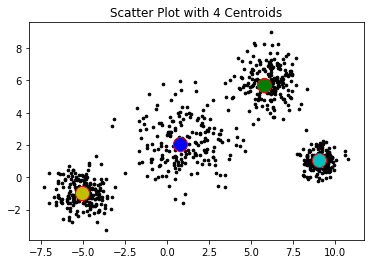

```python
plotting()
```

#### Even better now compared to the second iteration.

### Fourth Attempt

```python
finding_cluster()
find_centres()
centres
```

```
array([[ 5.97243759,  5.88784838],
       [ 0.93973117,  2.13879788],
       [-5.05717014, -0.94967031],
       [ 9.063639  ,  1.04633907]])
```

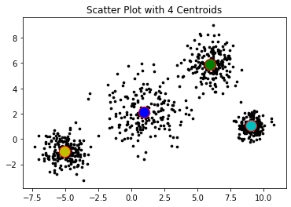

```python
plotting()
```

```python
finding_cluster()
find_centres()
centres
```

```
array([[ 6.0053298 ,  5.92528865],
       [ 0.98297825,  2.15787959],
       [-5.05717014, -0.94967031],
       [ 9.063639  ,  1.04633907]])
```

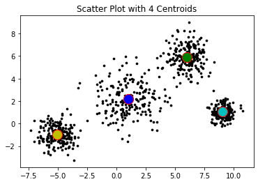

```python
plotting()
```